# Pythonでhistgramを描く方法まとめ

Pythonの以下のライブラリを使ってhistgramを描く。

- pandas
- matplotlib
- seaborn
- plotly, plotly-express
- bokeh

以下のような細かい設定・よく使う設定もなるべく一緒にまとめる。

- binの設定
- ラベル別のhistgram
- 違う列データもまとめて表示

## 実行環境

- mac OS Catalina
- pipenv

```python
!python --version
```

```
Python 3.7.4
```

```python
!pip list | grep -E '^(pandas|numpy|scikit-learn|matplotlib|seaborn|plotly|plotly-express|bokeh) '
```

```
bokeh              2.0.1
matplotlib         3.2.1
numpy              1.18.2
pandas             1.0.3
plotly             4.6.0
plotly-express     0.4.1
scikit-learn       0.22.2.post1
seaborn            0.10.0
```

## パッケージをimportしておく

```python
import os, sys

import numpy as np
import pandas as pd

import matplotlib.pyplot as plt
import seaborn as sns
import plotly
import bokeh

%matplotlib inline
```

# データを準備する

scikit-learnの [load_iris()](https://scikit-learn.org/stable/modules/generated/sklearn.datasets.load_iris.html?highlight=load_iris#sklearn.datasets.load_iris) をDataFrameに格納して使う

詳しいデータの内容は [7.2.2. Iris plants dataset](https://scikit-learn.org/stable/datasets/index.html#iris-dataset) を参照。

- データだけのDataFrame `df`
- 品種情報 (target_name) も追加したDataFrame、 `dft`

以上の2つを用意する。

```python
from sklearn.datasets import load_iris

iris = load_iris()
df = pd.DataFrame(iris.data, columns=iris.feature_names)
df.head()
```

|  | sepal length (cm) | sepal width (cm) | petal length (cm) | petal width (cm) |
| --- | --- | --- | --- | --- |
| 0 | 5.1 | 3.5 | 1.4 | 0.2 |
| 1 | 4.9 | 3.0 | 1.4 | 0.2 |
| 2 | 4.7 | 3.2 | 1.3 | 0.2 |
| 3 | 4.6 | 3.1 | 1.5 | 0.2 |
| 4 | 5.0 | 3.6 | 1.4 | 0.2 |

```python
dft = df.copy()
dft['target'] = iris.target
dft['target_name'] = dft.target.replace({i: name for i, name in enumerate(iris.target_names)})
dft.head()
```

|  | sepal length (cm) | sepal width (cm) | petal length (cm) | petal width (cm) | target | target_name |
| --- | --- | --- | --- | --- | --- | --- |
| 0 | 5.1 | 3.5 | 1.4 | 0.2 | 0 | setosa |
| 1 | 4.9 | 3.0 | 1.4 | 0.2 | 0 | setosa |
| 2 | 4.7 | 3.2 | 1.3 | 0.2 | 0 | setosa |
| 3 | 4.6 | 3.1 | 1.5 | 0.2 | 0 | setosa |
| 4 | 5.0 | 3.6 | 1.4 | 0.2 | 0 | setosa |

# pandas

pandasはmatpllotlibを呼び出す。細かい設定をするときの引数はmatplotlibと同じ。

DataFrameに対するhistgramは、[DataFrame.hist()](https://pandas.pydata.org/pandas-docs/stable/reference/api/pandas.DataFrame.hist.html) と [DataFrame.plot.hist()](https://pandas.pydata.org/pandas-docs/stable/reference/api/pandas.DataFrame.plot.hist.html) の2種類あり、出力が微妙に異なる。

- `df.hist()` はカラムごとにグラフを出力する
  - x軸・y軸やbinが揃っていないので、揃えたい場合は引数を渡す
    - x軸・y軸を揃えたいときの引数は、それぞれ `sharex=True`, `sharey=True`
    - binを揃えたいときはrangeを指定する e.g. `range=(0, df.max().max())`
- `df.plot.hist()` は全てのカラムを1つのグラフに出力する
  - デフォルトでhistgramが重なって胃しまうので、`alpha` を指定することで透明度を変更
  - `stacked=True` にすることで積み上げ

```python
# v1.0.0から backendを指定できるようになったのでmatplotlibかどうか確認
pd.options.plotting.backend
```

```
'matplotlib'
```

```
array([[<matplotlib.axes._subplots.AxesSubplot object at 0x11f4e5890>,
      dtype=object)
```

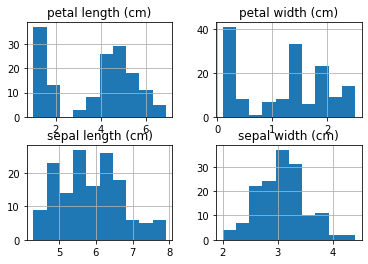

```python
df.hist()
```

```
array([[<matplotlib.axes._subplots.AxesSubplot object at 0x1216a3110>,
      dtype=object)
```

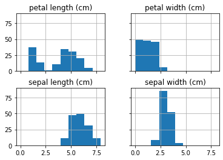

```python
# rangeを統一する
df.hist(sharex=True, sharey=True, range=(0, df.max().max()))
```

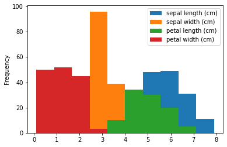

```python
df.plot.hist()
```

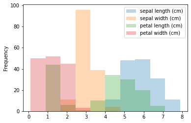

```python
df.plot.hist(alpha=0.3)
```

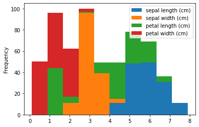

```python
df.plot.hist(stacked=True)
```

## Series, Groupby histgram

SeriesやgroupbyしたDataFrameに対しても `hist()` 関数は実装されている。

- [DataFrameGroupBy.hist](https://pandas.pydata.org/pandas-docs/stable/reference/api/pandas.core.groupby.DataFrameGroupBy.hist.html)
- [Series.plot.hist](https://pandas.pydata.org/pandas-docs/stable/reference/api/pandas.Series.hist.html)

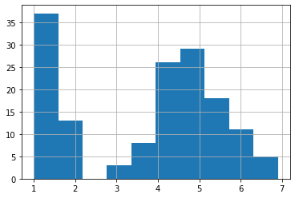

```python
df['petal length (cm)'].hist()
```

```
target_name
setosa        [[AxesSubplot(0.125,0.125;0.775x0.755)]]
versicolor    [[AxesSubplot(0.125,0.125;0.775x0.755)]]
virginica     [[AxesSubplot(0.125,0.125;0.775x0.755)]]
dtype: object
```

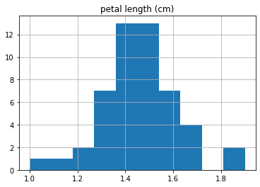

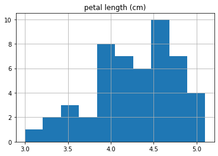

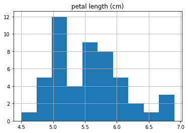

```python
dft[['petal length (cm)', 'target_name']].groupby('target_name').hist()
```

## ラベルごとのhistgram

ラベル (`target_name`)ごとのhistgramは `groupby()` や `pivot()` を使えばうまく出力できる

```
target_name
setosa        AxesSubplot(0.125,0.125;0.775x0.755)
versicolor    AxesSubplot(0.125,0.125;0.775x0.755)
virginica     AxesSubplot(0.125,0.125;0.775x0.755)
Name: petal length (cm), dtype: object
```

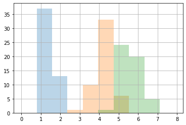

```python
dft.groupby('target_name')['petal length (cm)'].hist(range=(0,df.max().max()), alpha=0.3)
```

```
array([[<matplotlib.axes._subplots.AxesSubplot object at 0x1222d7550>,
      dtype=object)
```

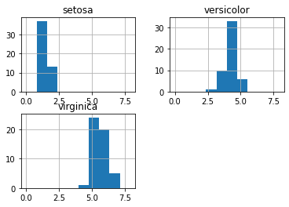

```python
dft.pivot(columns='target_name')['petal length (cm)'].hist(range=(0,df.max().max()))
```

# matplotlib

pandasが呼び出しているのは `plt.hist()`

- [plt.hist()](https://matplotlib.org/api/_as_gen/matplotlib.pyplot.hist.html)
  - 渡すデータ `x` は `(n,) array or sequence of (n,) arrays` なので、DataFrameを渡すときは注意

```
(150, 1)
```

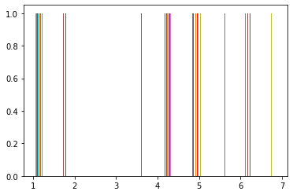

```python
# NG
print(df[['petal length (cm)']].shape)
plt.hist(x=df[['petal length (cm)']])
```

```
(150,)
```

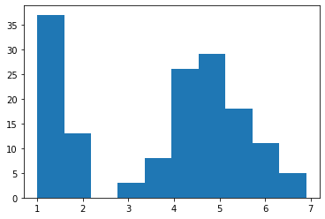

```python
# OK
print(df.loc[:,'petal length (cm)'].shape)
plt.hist(x=df.loc[:,'petal length (cm)'])
```

## 凡例の表示

`label` にラベル名(カラム名)を渡し、 `plt.legend()`を実行すると、凡例を出力できる

凡例の位置は調整可能 (参考: https://qiita.com/matsui-k20xx/items/291400ed56a39ed63462)

```
(2, 150)
```

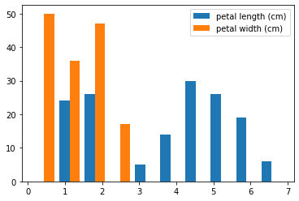

```python
cols = ['petal length (cm)','petal width (cm)']
print(df.loc[:,cols].T.shape)
plt.hist(x=df.loc[:,cols].T, label=cols)
plt.legend()
```

## 表示設定

`histtype` を指定すると、細かい設定をせずに出力できる

typeは `{'bar', 'barstacked', 'step', 'stepfilled'}` の4種類ある。

(参考 https://matplotlib.org/3.1.1/gallery/statistics/histogram_multihist.html)

また、複数のグラフを表示したいときは `subplots` を使う (参考 [matplotlib.pyplot.subplots](https://matplotlib.org/3.2.1/api/_as_gen/matplotlib.pyplot.subplots.html))

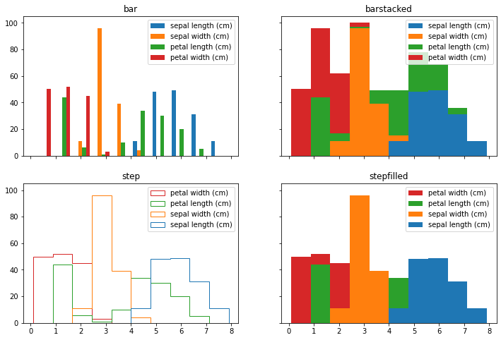

```python
fig, axes = plt.subplots(nrows=2, ncols=2, sharex=True, sharey=True, figsize=(12, 8))

for htype,ax in zip(['bar', 'barstacked', 'step', 'stepfilled'], axes.flatten()):
    ax.hist(iris.data, histtype=htype, label=iris.feature_names, bins=10)
    ax.set_title(htype)
    ax.legend(loc='upper right')

# fig.show()
```

### save graph

`savefig()` で保存

```python
fig.savefig('matplotlib_sample.png')
```

## ラベルごと・複数データに対するhistgram(matplotlib編)

`sequence of (n,) arrays` であれば、`label`にラベル名を渡すことができる。

異なる場所にあるデータを1つのhistgramに集約させたい場合は`plt.hist()` を重ねればよい。

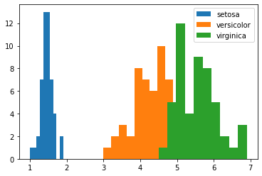

```python
fig, ax = plt.subplots(1,1)

for n in iris.target_names:
    # DataFrameでは本来バラバラで渡す必要はないけど、具体例のためにtarget_nameのデータを取り出しています
    x= dft.query('target_name=="{}"'.format(n))['petal length (cm)']
    ax.hist(x=x, label=n)

ax.legend(loc='upper right')
# fig.show()
```

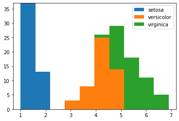

```python
fig, ax = plt.subplots(1,1)

x_data = []
for n in iris.target_names:
    x_data.append(dft.query('target_name=="{}"'.format(n))['petal length (cm)'])

# listで一気に渡してもよい
ax.hist(x=x_data, label=iris.target_names, histtype='barstacked')
ax.legend(loc='upper right')
# fig.show()
```

# seaborn

`sns.hist()` はない。histgramに適しているのは [sns.distplot](https://seaborn.pydata.org/generated/seaborn.distplot.html)

- `kde` (kernel density estimate) がデフォルトで `True` になっている
  - 必要ないときは `kde=False` にする
- 渡すことのできるデータ `a` が `Series, 1d-array, or list` なのでSeriesをそのまま渡しても予想通りの挙動をする

だいたいmatplotlibと同じように使えるが、ちょいちょい使い勝手が違うので、`sns.set()`して、matplotlib使う方が正直楽なところもある。

```python
sns.set()
```

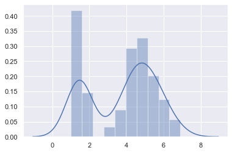

```python
sns.distplot(df[['petal length (cm)']], bins=10)
```

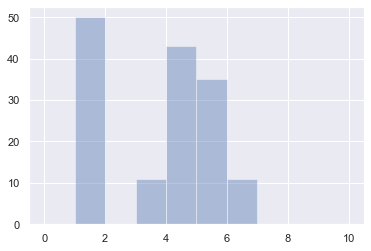

```python
# rangeなど matplotlib側の設定を変えたいときは hist_kws で渡す
sns.distplot(df[['petal length (cm)']], bins=10,kde=False, hist_kws={'range':(0,10)})
```

## ラベルごと・複数データに対するhistgram(seaborn編)

seabornでは1次元配列しか受け取れない。

そのため、複数データを1つのhistgramに集約させたい場合は`sns.distplot()` を重ねる必要がある。

`histtype` は設定できないので、stackしたり、ならべたいなら ラベルごと・複数データに対するhistgram(matplotlib編)) の方法で。

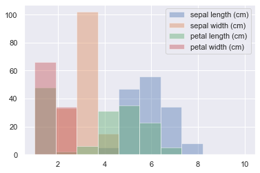

```python
for i in range(4):
    sns.distplot(iris.data[:,i],
                 label=iris.feature_names[i],
                 kde=False,
                 bins=10,
                 hist_kws={'range': [1,10]}
                )

plt.legend()
```

### save

matplotlibと同じ

```python
plt.savefig('seaborn_sample.png')
```

# plotly

plotlyはjavascriptベースで、tooltipを自動で設定してくれるのが良い。見た目もデフォルトのままで使える。

kaggleのkernelでもよくみる。

plotlyそのままだと書くコード量が多くなる。 なるべくplotly-expressを使いたい。

細かい調整をしたくなると、結局plotly本体の設定を変更することになる。

histgramについてはだいたい https://plotly.com/python/histograms/ のページで解決する。

(参考 https://qiita.com/inoory/items/12028af62018bf367722)

## plotlyだけでhistgram

plotly-expressを使わず、plotlyだけでhistgramを描くには`go.Figure()`と`go.Histgram()`を使う。

`go.Figure()` に `go.Histgram()`のリストを渡すことで複数データのhistgramを作成できる。

```python
import plotly
import plotly.graph_objs as go

# offlineで使う
plotly.offline.init_notebook_mode(connected=False)
# 以降、offlineで使う場合は fig.show()をplotly.offline.iplot(fig)に置き換える
```

```python
fig = go.Figure(data=go.Histogram(x=iris.data[:,0]))
fig.show()
```

[interactive chart not shown]

```python
# target_name ごとのhistgramを一緒に表示
data=[
    go.Histogram(x=dft.query('target_name=="{}"'.format(n))['petal length (cm)'], name=n)
      for n
    in iris.target_names
]

fig = go.Figure(data=data)
fig.show()
```

[interactive chart not shown]

- 範囲 (range) 設定は `xbins` で行う。
- また、`data` はリストでなくても `add_trace` で逐一追加することも可能

```python
fig = go.Figure()

for i in range(len(iris.feature_names)):
    fig.add_trace(go.Histogram(x=iris.data[:,i], name=iris.feature_names[i],
                 xbins={'start':0, 'end':10, 'size':1}))

fig.show()
```

[interactive chart not shown]

### save

- htmlでも出力できる https://plotly.com/python/interactive-html-export/
- offline で保存する場合は引数にfilenameを渡す
  - 参考 http://python.zombie-hunting-club.com/entry/2017/11/03/223753#3-オフラインで使ってみる

```python
plotly.offline.plot(fig, filename='plotly_sample.html')
```

```
'plotly_sample.html'
```

### barmode

- barmode でレイアウトが変更できる
  - モードは `"stack" | "group" | "overlay" | "relative"`
  - `go.Layout(barmode='ove')` を `go.Figure()`に渡すか、 `fig.updte_layout()` で一気に更新する
- 透明度は `opacity`
  - `go.Histgram()` で逐一指定するか、 `fig.update_traces()`で一気に更新する

```python
data=[
    go.Histogram(x=iris.data[:,i], name=iris.feature_names[i],
                 xbins={'start':0, 'end':10, 'size':0.5})
      for i
    in range(len(iris.feature_names))
]

layout = go.Layout(barmode='overlay')
fig = go.Figure(data=data, layout=layout)
fig.update_traces(opacity=0.3)
fig.show()
```

[interactive chart not shown]

```python
data=[
    go.Histogram(x=iris.data[:,i], name=iris.feature_names[i],
                 xbins={'start':0, 'end':10, 'size':0.5},
                opacity=0.8)
      for i
    in range(len(iris.feature_names))
]

layout = go.Layout(barmode='stack')
fig = go.Figure(data=data, layout=layout)
fig.show()
```

[interactive chart not shown]

### plotly.subplots

matplotlibと同じように複数グラフを表示できる (参考 https://plotly.com/python/subplots/)

```python
from plotly.subplots import make_subplots

fig = make_subplots(rows=1, cols=2)


fig.add_trace(
    go.Histogram(x=iris.data[:,0], name=iris.feature_names[0],
                 xbins={'start':0, 'end':10, 'size':0.5}),
    row=1, col=1
)

fig.add_trace(
    go.Histogram(x=iris.data[:,1], name=iris.feature_names[1],
                 xbins={'start':0, 'end':10, 'size':0.5}),
    row=1, col=2
)

fig.update_layout(title_text="plotly.subplot")
fig.show()
```

[interactive chart not shown]

# plotly-express

plotlyを楽に呼び出して使える

- DataFrameとカラム名を渡すだけでhistgramが描ける
- `color` にカラム名を渡せば、渡したカラムごとに色分けできる
- 細かい設定の引数はplotlyと同じ (`opacity` など)

```python
import plotly.express as px
fig = px.histogram(df, x='petal length (cm)')
fig.show()
```

[interactive chart not shown]

```python
fig = px.histogram(dft, x='petal length (cm)', color='target_name')
fig.show()
```

[interactive chart not shown]

```python
fig = px.histogram(dft, x='petal length (cm)', color='target_name', opacity=0.3)
fig.update_layout(barmode='overlay')
fig.show()
```

[interactive chart not shown]

### plotly-express and subplots

`color` など細かい設定には対応していない

(参考 https://github.com/plotly/plotly_express/issues/83)

```python
fig = make_subplots(rows=1, cols=2)

fig.add_trace(
    px.histogram(dft, x='petal length (cm)')['data'][0],
    row=1, col=1
)

fig.add_trace(
    px.histogram(dft, x='petal width (cm)')['data'][0],
    row=1, col=2
)

fig.update_layout(title_text="length and width")
fig.show()
```

[interactive chart not shown]

# bokeh

bokeh自体にhistgram機能はないので、棒グラフ(`vbar`) にnumpyで算出したhistgramの値を渡す必要がある

参考

- https://docs.bokeh.org/en/latest/docs/gallery/histogram.html
- https://docs.bokeh.org/en/latest/docs/gallery/bar_stacked.html

```python
import bokeh

from bokeh.io import output_notebook, show
from bokeh.plotting import figure, output_file, show
output_notebook()
```

```python
# データの作成
hist, edges = np.histogram(iris.data[:,0], range=(0,10), bins=10)
edges, hist
```

```
(array([ 0.,  1.,  2.,  3.,  4.,  5.,  6.,  7.,  8.,  9., 10.]),
 array([ 0,  0,  0,  0, 22, 61, 54, 13,  0,  0]))
```

```python
len(hist), len(edges)
```

```
(10, 11)
```

```python
from bokeh.plotting import ColumnDataSource

source = ColumnDataSource(data=dict(
    x=edges[:-1],
    y=hist,
    name=edges[:-1],
))

p = figure(plot_height=350,
           title=iris.feature_names[0],
           toolbar_location=None,
           tools="hover",
           tooltips="x: @x y: @y"
          )

p.vbar(top='y',x='x', width=0.9, source=source)

p.y_range.start = 0
show(p)
```

[interactive chart not shown]

### save

- https://docs.bokeh.org/en/latest/docs/user_guide/export.html
- 詳しくは割愛